# Analysis of longitudinal data

*What follows is my report for the IODS course exercise 6 that focuses exploring longitudinal data as well as performing and interpreting linear mixed effects models.*

```r
# necessary libraries
library(ggplot2)
library(dplyr)
library(lme4)
```

I previously prepared two open-source data sets for this analysis that are later looked upon more deeply (data sources: https://raw.githubusercontent.com/KimmoVehkalahti/MABS/master/Examples/data/BPRS.txt and https://raw.githubusercontent.com/KimmoVehkalahti/MABS/master/Examples/data/rats.txt). The data was transformed from wide to long format. After loading the data, I had to factor two variables in each data set: the identification variable and the treatment group variable.

```r
# read in previously prepared data
bprs <- read.table("data\\bprs.csv", header = TRUE, sep = ",")
rats <- read.table("data\\rats.csv", header = TRUE, sep = ",")

# convert categorical ID and treatment group variables to factors
bprs$subject <- factor(bprs$subject)
bprs$treatment <- factor(bprs$treatment)
rats$ID <- factor(rats$ID)
rats$Group <- factor(rats$Group)
```

### Exploring the *RATS* data

In this part, I am going to explore the longitudinal nature of the *RATS* data set. It contains information of 16 rats (variable *ID*) and their weight trajectories (variable *weight*) over a period of 9 weeks (variable *time*. The rats were assigned to three different groups (variable *Group*) and were fed a different diet, respectively. The plot shows the development of each rat’s weight over the 9 weeks. The colors red, blue and green differentiate the different diet groups. For the majority of the rats, the weight is increasing over time. If it is not increasing, their weight seems to be at least steady. Further, the phenomenon of *tracking* is visible in the plot, meaning, that rats that started with a higher weight tend to have a higher weight throughout the study.

```r
# structure and dimension of the data
str(rats)
```

```
## 'data.frame':    176 obs. of  5 variables:
##  $ ID    : Factor w/ 16 levels "1","2","3","4",..: 1 2 3 4 5 6 7 8 9 10 ...
##  $ Group : Factor w/ 3 levels "1","2","3": 1 1 1 1 1 1 1 1 2 2 ...
##  $ times : Factor w/ 11 levels "WD1","WD15","WD22",..: 1 1 1 1 1 1 1 1 1 1 ...
##  $ weight: int  240 225 245 260 255 260 275 245 410 405 ...
##  $ time  : int  1 1 1 1 1 1 1 1 1 1 ...
```

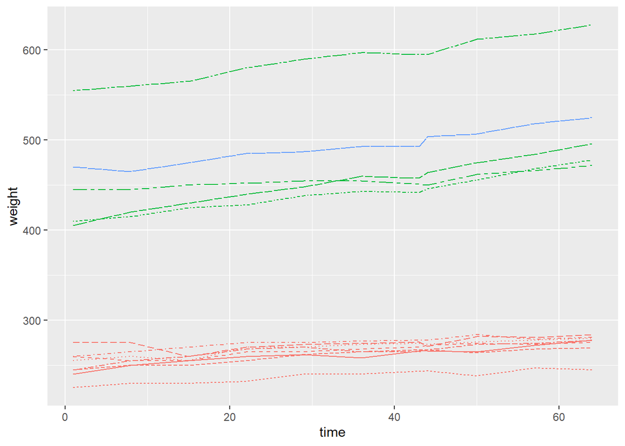

```r
# plot to explore the data
rats %>% ggplot(aes(x = time, y = weight, color = Group)) +
  geom_line(aes(linetype = ID)) +
  theme(legend.position = "none")
```

I standardized the weight variable in an attempt to see the tracking more clearly. However, in the new plot, we can see that there are rats that have a decreased (standardized) weight in the red and the green group. In addition, there are more rats that have a stable weight development. From these two plots, it is difficult to see whether there is a difference in weight gain or loss between the rats with different diets.

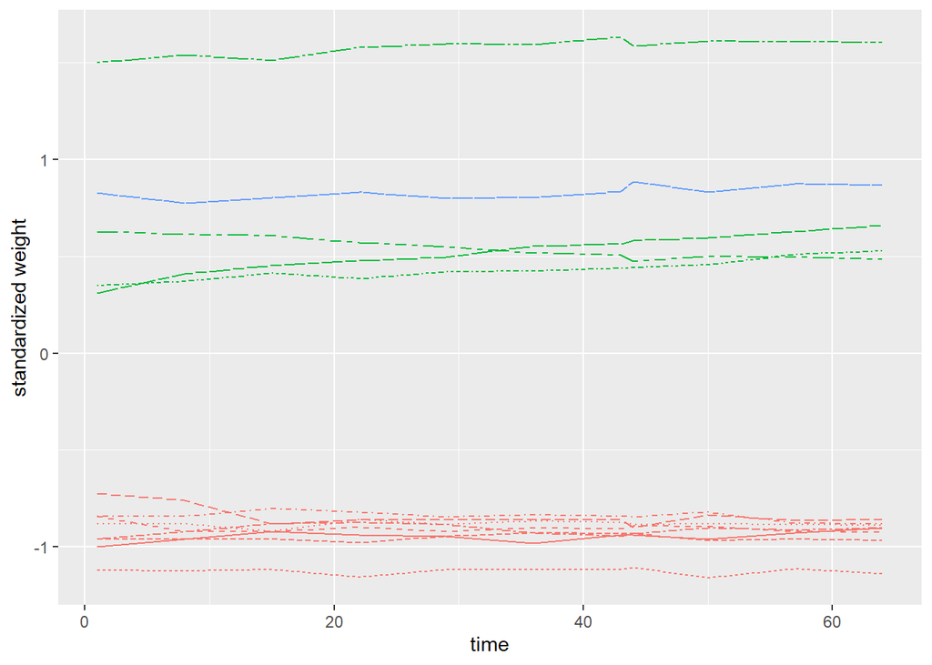

```r
# standardize the weight variable
rats <- rats %>% group_by(time) %>% mutate(std_weight = scale(weight)) %>% ungroup()

# plot with standardized weight
rats %>% ggplot(aes(x = time, y = std_weight, color = Group)) +
  geom_line(aes(linetype = ID)) +
  theme(legend.position = "none") +
  scale_y_continuous(name = "standardized weight")
```

To further explore this issue, I looked at the longitudinal data using a summary measure method. I wanted to know weather a rat’s final weight compared to the weight in the beginning of the study is different for the three groups of rats on different diets. Therefore, I chose the percentage change between the last and the first weight as a summary measure. The percentage change is defined as follows: 100 * (last weight - first weight) / first weight). After calculating the summary measure, I created a scatter plot with the percentage change for each individual rat by diet group. From this plot, we can easily see that diet group 1 consists of 8 rats while there are only 4 rats in the other two groups. The next plot shows scatter plots of the percentage change by group. We can see, that the weight of the rats with diet 2 changed more strongly throughout the study (median percentage change of 15) than the weight of rats in groups 1 (median percentage change of 9) and 3 (median percentage change of 8). In addition, there seems to be an outlier in group one with an exeptionally strong percentage change for this group.

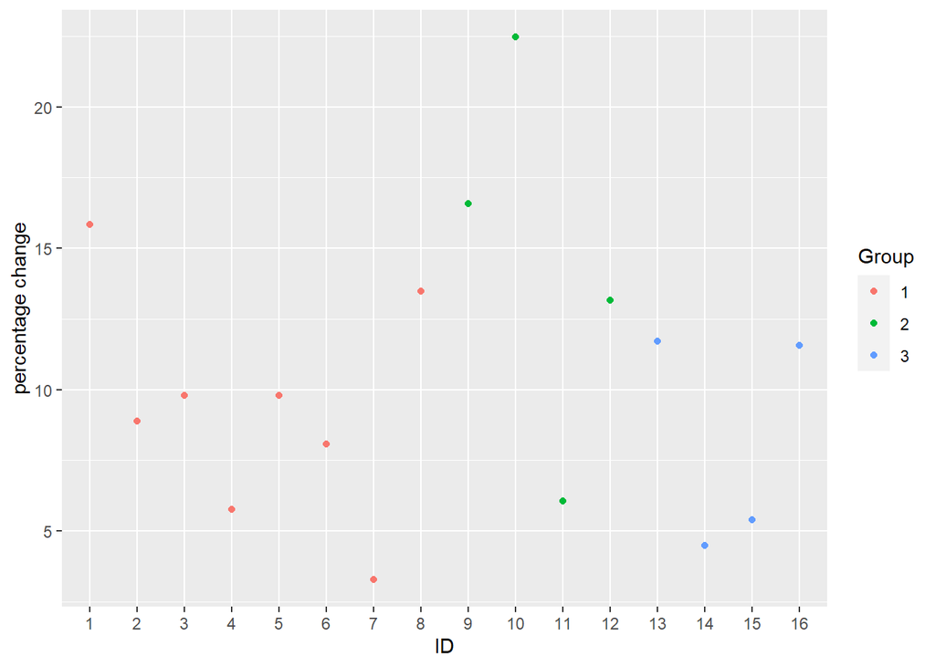

```r
# calculate the percentage change between first and last value of weight
rats <- rats %>% group_by(ID) %>% mutate(p.change = 100 * (weight[time == 64]-weight[time == 1])/weight[time == 1]) %>% ungroup()

# plot the percentage change by group of diet

# scatter plot
rats %>% ggplot(aes(x = ID, y = p.change, color = Group)) +
  geom_point() +
  scale_y_continuous(name = "percentage change")
```

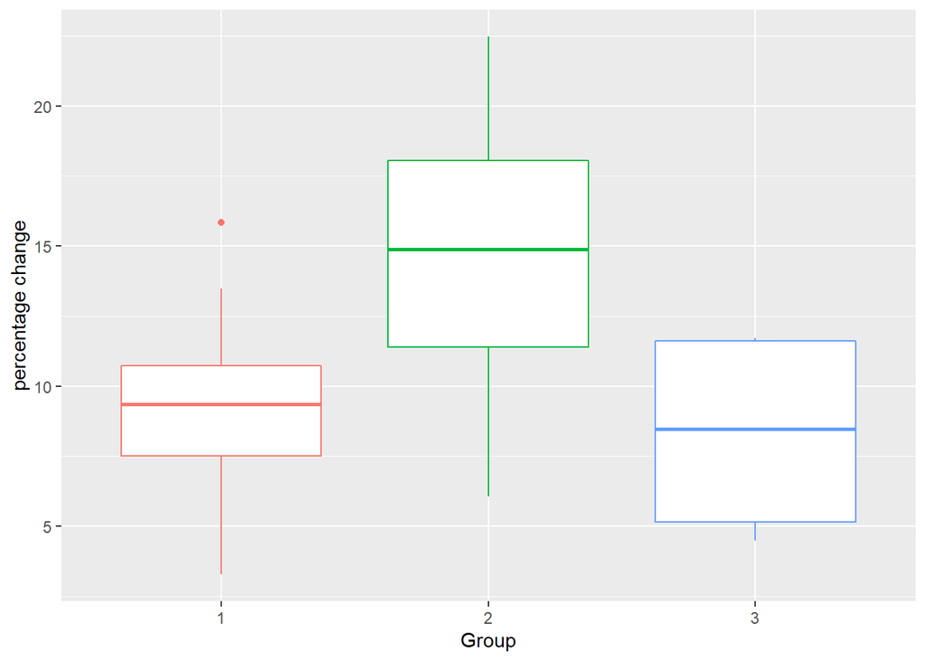

```r
# boxplot
rats %>% ggplot(aes(x = Group, y = p.change, color = Group)) +
  geom_boxplot() +
  theme(legend.position = "none") +
  scale_y_continuous(name = "percentage change")
```

To avoid any bias in the analysis because of this outlier I excluded the respective rat (*ID* = 1) from the data. After plotting the boxplots again, we can see that the general interpretation did not change. However, the difference in weight change between diet groups 2 and 1 is even more pronounced which is not surprising after excluing a high value in group one in the data. Still, the differences in weight development for rats in group 1 and group 3 does not differ much.

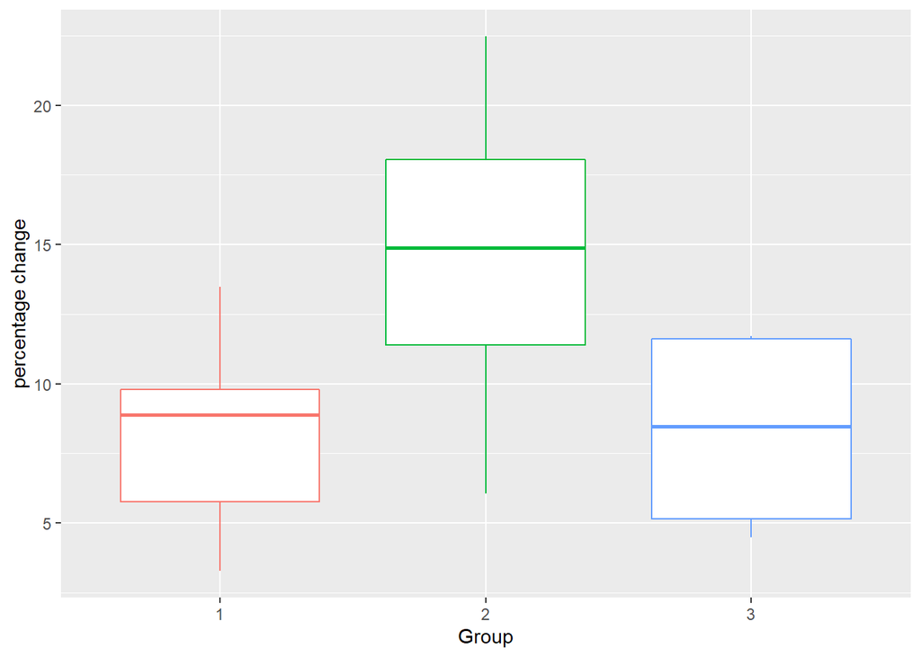

```r
# remove outlier
rats.nice <- rats %>% filter(ID != 1)

# boxplot
rats.nice %>% ggplot(aes(x = Group, y = p.change, color = Group)) +
  geom_boxplot() +
  theme(legend.position = "none") +
  scale_y_continuous(name = "percentage change")
```

### Mixed effects model with *BPRS* data

In the following, I will use data on 40 men (variable *subject*) and their BPRS score for schizophrenia (variable *bprs*) that has been assessed over a period of 8 weeks (variable *week*). The BPRS (brief psychiatric rating scale) measures 18 symptoms on a scale from 1 (not present) to 7 (extremely severe). The subjects were assigned to two different treatment groups (variable *treatment*) after an initial baseline measure (*week* = 0) and have been repeatedly evaluated every week. To begin with, I proceeded with this data like I did with the *RATS* data: First, I plotted the bprs score development over the weeks for each individual and separately for the two treatment groups. From eyeballing, it is hard to conclude anything about differences in score development because of the different treatments. The tracking phenomenon in present in both groups. After standardizing the BPRS variable to see the tracking more clearly, it is still hard to answer the question whether the two groups differ in their development of the score over time. Therefore, we need more advanced methods called linear mixed effects models that take therepeated measures and their non-independence into account.

```r
# strcture and dimension of the data
str(bprs)
```

```
## 'data.frame':    360 obs. of  5 variables:
##  $ treatment: Factor w/ 2 levels "1","2": 1 1 1 1 1 1 1 1 1 1 ...
##  $ subject  : Factor w/ 20 levels "1","2","3","4",..: 1 2 3 4 5 6 7 8 9 10 ...
##  $ weeks    : Factor w/ 9 levels "week0","week1",..: 1 1 1 1 1 1 1 1 1 1 ...
##  $ bprs     : int  42 58 54 55 72 48 71 30 41 57 ...
##  $ week     : int  0 0 0 0 0 0 0 0 0 0 ...
```

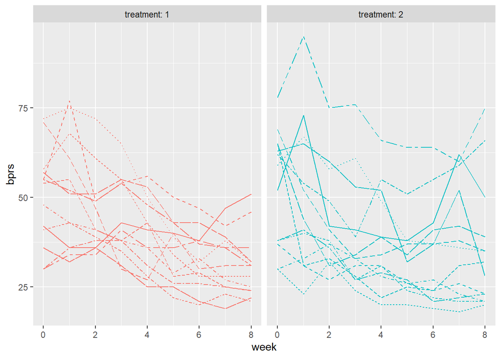

```r
# plot to explore the data
bprs %>% ggplot(aes(x = week, y = bprs, color = treatment)) +
  geom_line(aes(linetype = subject)) +
  facet_grid(. ~ treatment, labeller = label_both) +
  theme(legend.position = "none")
```

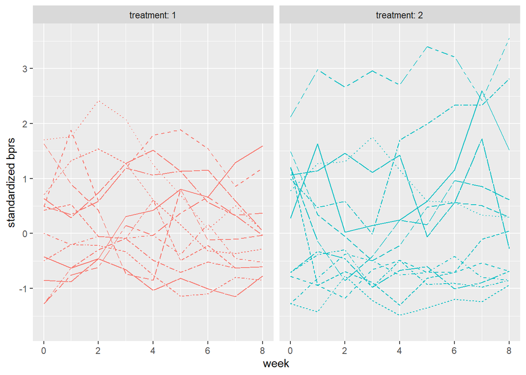

```r
# standardize the bprs variable
bprs <- bprs %>% group_by(week) %>% mutate(std_bprs = scale(bprs)) %>% ungroup()

# plot with standardized weight
bprs %>% ggplot(aes(x = week, y = std_bprs, color = treatment)) +
  geom_line(aes(linetype = subject)) +
  facet_grid(. ~ treatment, labeller = label_both) +
  theme(legend.position = "none") +
  scale_y_continuous(name = "standardized bprs")
```

I started by fitting a random intercet model on the data. The response variable is *bprs* and the explanatory variables are *week* and *treatment*. I have to stop the interpretation of my results here as I have to prioritize and other parts of my doctoral research are urgent at the moment. In short: The random intercept and random slope model is better than just the random intercept model. And the model with interaction term is not better than the random intercept and slope model.

```r
# fit a random intercept model
bprs_rim <- lmer(bprs ~ week + treatment + (1 | subject), data = bprs, REML = FALSE)

# summary of the random intercept model
summary(bprs_rim)
```

```
## Linear mixed model fit by maximum likelihood  ['lmerMod']
## Formula: bprs ~ week + treatment + (1 | subject)
##    Data: bprs
##
##      AIC      BIC   logLik deviance df.resid
##   2748.7   2768.1  -1369.4   2738.7      355
##
## Scaled residuals:
##     Min      1Q  Median      3Q     Max
## -3.0481 -0.6749 -0.1361  0.4813  3.4855
##
## Random effects:
##  Groups   Name        Variance Std.Dev.
##  subject  (Intercept)  47.41    6.885
##  Residual             104.21   10.208
## Number of obs: 360, groups:  subject, 20
##
## Fixed effects:
##             Estimate Std. Error t value
## (Intercept)  46.4539     1.9090  24.334
## week         -2.2704     0.2084 -10.896
## treatment2    0.5722     1.0761   0.532
##
## Correlation of Fixed Effects:
##            (Intr) week
## week       -0.437
## treatment2 -0.282  0.000
```

```r
# create a random intercept and random slope model
bprs_rim_rsm <- lmer(bprs ~ week + treatment + (week | subject), data = bprs, REML = FALSE)

# print a summary of the model
summary(bprs_rim_rsm)
```

```
## Linear mixed model fit by maximum likelihood  ['lmerMod']
## Formula: bprs ~ week + treatment + (week | subject)
##    Data: bprs
##
##      AIC      BIC   logLik deviance df.resid
##   2745.4   2772.6  -1365.7   2731.4      353
##
## Scaled residuals:
##     Min      1Q  Median      3Q     Max
## -2.8919 -0.6194 -0.0691  0.5531  3.7976
##
## Random effects:
##  Groups   Name        Variance Std.Dev. Corr
##  subject  (Intercept) 64.8222  8.0512
##           week         0.9609  0.9802   -0.51
##  Residual             97.4305  9.8707
## Number of obs: 360, groups:  subject, 20
##
## Fixed effects:
##             Estimate Std. Error t value
## (Intercept)  46.4539     2.1052  22.066
## week         -2.2704     0.2977  -7.626
## treatment2    0.5722     1.0405   0.550
##
## Correlation of Fixed Effects:
##            (Intr) week
## week       -0.582
## treatment2 -0.247  0.000
```

```r
# perform an ANOVA test on the two models
anova(bprs_rim_rsm, bprs_rim)
```

```
## Data: bprs
## Models:
## bprs_rim: bprs ~ week + treatment + (1 | subject)
## bprs_rim_rsm: bprs ~ week + treatment + (week | subject)
##              npar    AIC    BIC  logLik deviance  Chisq Df Pr(>Chisq)
## bprs_rim        5 2748.7 2768.1 -1369.4   2738.7
## bprs_rim_rsm    7 2745.4 2772.6 -1365.7   2731.4 7.2721  2    0.02636 *
## ---
## Signif. codes:  0 '***' 0.001 '**' 0.01 '*' 0.05 '.' 0.1 ' ' 1
```

```r
# create a random intercept and random slope model with the interaction
bprs_inter <- lmer(bprs ~ week + treatment + (week | subject) + week * treatment, data = bprs, REML = FALSE)

# print a summary of the model
summary(bprs_inter)
```

```
## Linear mixed model fit by maximum likelihood  ['lmerMod']
## Formula: bprs ~ week + treatment + (week | subject) + week * treatment
##    Data: bprs
##
##      AIC      BIC   logLik deviance df.resid
##   2744.3   2775.4  -1364.1   2728.3      352
##
## Scaled residuals:
##     Min      1Q  Median      3Q     Max
## -3.0512 -0.6271 -0.0768  0.5288  3.9260
##
## Random effects:
##  Groups   Name        Variance Std.Dev. Corr
##  subject  (Intercept) 64.9964  8.0620
##           week         0.9687  0.9842   -0.51
##  Residual             96.4707  9.8220
## Number of obs: 360, groups:  subject, 20
##
## Fixed effects:
##                 Estimate Std. Error t value
## (Intercept)      47.8856     2.2521  21.262
## week             -2.6283     0.3589  -7.323
## treatment2       -2.2911     1.9090  -1.200
## week:treatment2   0.7158     0.4010   1.785
##
## Correlation of Fixed Effects:
##             (Intr) week   trtmn2
## week        -0.650
## treatment2  -0.424  0.469
## wek:trtmnt2  0.356 -0.559 -0.840
```

```r
# perform an ANOVA test on the two models
anova(bprs_inter, bprs_rim_rsm)
```

```
## Data: bprs
## Models:
## bprs_rim_rsm: bprs ~ week + treatment + (week | subject)
## bprs_inter: bprs ~ week + treatment + (week | subject) + week * treatment
##              npar    AIC    BIC  logLik deviance  Chisq Df Pr(>Chisq)
## bprs_rim_rsm    7 2745.4 2772.6 -1365.7   2731.4
## bprs_inter      8 2744.3 2775.4 -1364.1   2728.3 3.1712  1    0.07495 .
## ---
## Signif. codes:  0 '***' 0.001 '**' 0.01 '*' 0.05 '.' 0.1 ' ' 1
```

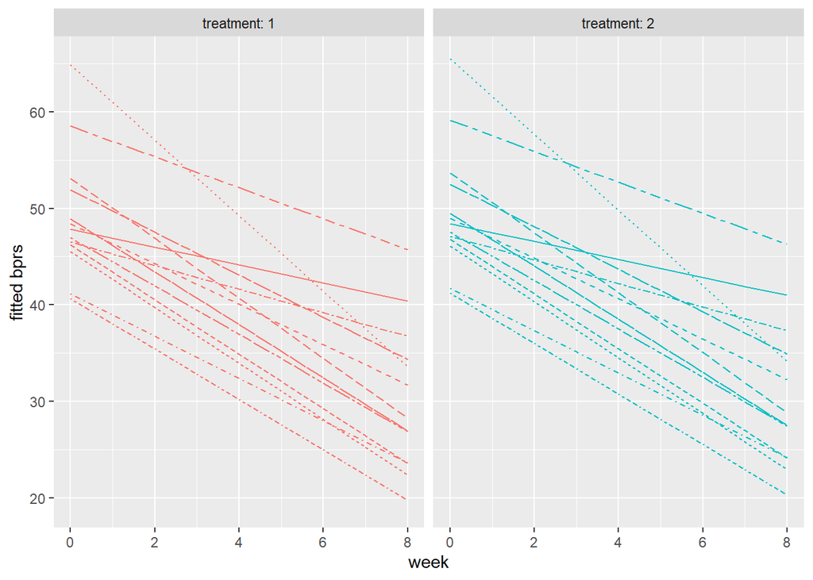

```r
# add fitted values to data
bprs$fitted <- fitted(bprs_rim_rsm)

# plot fitted values of bprs
bprs %>% ggplot(aes(x = week, y = fitted, color = treatment)) +
  geom_line(aes(linetype = subject)) +
  facet_grid(. ~ treatment, labeller = label_both) +
  theme(legend.position = "none") +
  scale_y_continuous(name = "fitted bprs")
```

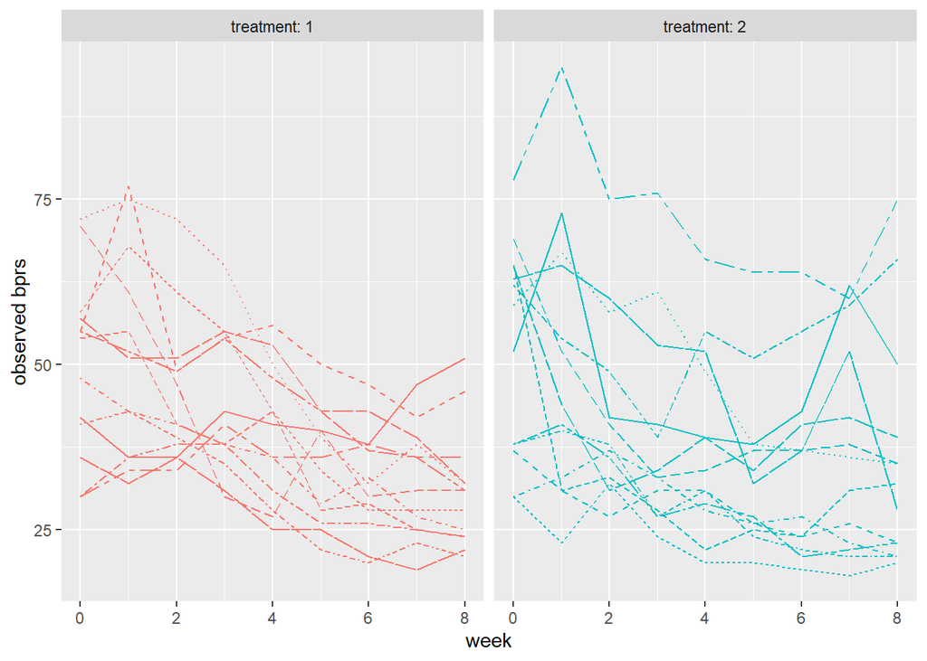

```r
# compare to original plot with observed bprs
bprs %>% ggplot(aes(x = week, y = bprs, color = treatment)) +
  geom_line(aes(linetype = subject)) +
  facet_grid(. ~ treatment, labeller = label_both) +
  theme(legend.position = "none") +
  scale_y_continuous(name = "observed bprs")
```